# Teste de Cultivares de Soja

Eng. Agrônomo Paulo Tchujo

# Introdução

No [facebook ZT sementes](https://www.facebook.com/ztsementes/), foram apresentados os dados do ensaio. A públicação está em formato de fotos com os resultados obtidos.  
O ensaio contou 10 empresas e 21 varidades.

# Objetivo

Melhorar a visualização gráfica da produtividade média das variedades de soja.

# Bibliotecas

As biblioteca utilizadas:

```r
library(readxl)
library(dplyr)
library(ggplot2)
library(forcats)
```

# Importando os dados

Os dados tratados estão disponiveis no [GitHub](https://github.com/PauloTchujo/Teste-Variedades-Soja).  
Inicialmente realizamos um tratamento dos dados no Excel, transformando em planilha, então importamos para o “*R*” realizando as analises.

```r
df_soja <- read_excel("Cultivares_Soja_Produtividades.xlsx")
```

# Primeira visualização dos Dados

```r
df_soja
```

```
## # A tibble: 147 x 11
##    Cultivar    Fabricante Local Data_Semeadura         GM  kgha Altura_Planta_cm
##    <chr>       <chr>      <chr> <dttm>              <dbl> <dbl>            <dbl>
##  1 NEO 610 IP~ Neogen Se~ Juli~ 2020-11-13 00:00:00   6.1  5144               92
##  2 BMX ZEUS I~ Brasmax S~ Juli~ 2020-11-13 00:00:00   5.5  4804               84
##  3 AS 3590 IP~ Agroest B~ Juli~ 2020-11-13 00:00:00   5.9  4729              113
##  4 DM 5958 RS~ Donmario ~ Juli~ 2020-11-13 00:00:00   5.8  4724               90
##  5 M 5947 IPRO Monsoy     Juli~ 2020-11-13 00:00:00   5.9  4710              105
##  6 BS 2606 IP~ Basf       Juli~ 2020-11-13 00:00:00   6    4696              118
##  7 M 5838 IPRO Monsoy     Juli~ 2020-11-13 00:00:00   5.8  4639               98
##  8 FPS 1859 RR Fundação ~ Juli~ 2020-11-13 00:00:00   5.9  4625               92
##  9 BMX DELTA ~ Brasmax S~ Juli~ 2020-11-13 00:00:00   5.9  4540               89
## 10 DM 57I52 R~ Donmario ~ Juli~ 2020-11-13 00:00:00   5.7  4437               87
## # ... with 137 more rows, and 4 more variables: Acamamento <dbl>,
## #   Ciclo_Florescimento <dbl>, Ciclo_maturacao <dbl>, Media_2anos_kgha <dbl>
```

# Quais os tipos de Dados

```r
str(df_soja)
```

```
## tibble [147 x 11] (S3: tbl_df/tbl/data.frame)
##  $ Cultivar           : chr [1:147] "NEO 610 IPRO" "BMX ZEUS IPRO" "AS 3590 IPRO" "DM 5958 RSF IPRO" ...
##  $ Fabricante         : chr [1:147] "Neogen Sementes" "Brasmax Sementes" "Agroest Bayer" "Donmario sementes" ...
##  $ Local              : chr [1:147] "Julio de Castilhos RS" "Julio de Castilhos RS" "Julio de Castilhos RS" "Julio de Castilhos RS" ...
##  $ Data_Semeadura     : POSIXct[1:147], format: "2020-11-13" "2020-11-13" ...
##  $ GM                 : num [1:147] 6.1 5.5 5.9 5.8 5.9 6 5.8 5.9 5.9 5.7 ...
##  $ kgha               : num [1:147] 5144 4804 4729 4724 4710 ...
##  $ Altura_Planta_cm   : num [1:147] 92 84 113 90 105 118 98 92 89 87 ...
##  $ Acamamento         : num [1:147] 0 0 0 0 0 0 0 0 0 0 ...
##  $ Ciclo_Florescimento: num [1:147] 55 31 55 50 48 59 53 51 53 48 ...
##  $ Ciclo_maturacao    : num [1:147] 133 124 139 132 137 138 136 134 133 126 ...
##  $ Media_2anos_kgha   : num [1:147] 0 4539 3963 4423 4222 ...
```

# Transformando os dados

Transformado dados do tipo “*caracteres*” em fatores

```r
df_soja$Cultivar <- as.factor(df_soja$Cultivar)
df_soja$Local <- as.factor(df_soja$Local)
df_soja$Data_Semeadura <- as.factor(df_soja$Data_Semeadura)
df_soja$GM <- as.factor(df_soja$GM)
```

# Analise estatistica Básica dos dados

```r
summary(df_soja)
```

```
##            Cultivar    Fabricante                          Local
##  95R51         :  7   Length:147         Cachoeira do Sul RS  :21
##  95R90 IPRO    :  7   Class :character   Julio de Castilhos RS:21
##  95Y02 IPRO    :  7   Mode  :character   Lagoa Vermelha RS    :21
##  AS 3590 IPRO  :  7                      Passo Fundo RS       :21
##  BMX ATIVA IPRO:  7                      Santo Augusto RS     :21
##  BMX DELTA IPRO:  7                      São Luiz Gonzaga RS  :42
##  (Other)       :105
##     Data_Semeadura       GM          kgha      Altura_Planta_cm
##  2020-10-28:21     5.9    :42   Min.   :   0   Min.   : 34.00
##  2020-10-29:21     5.8    :28   1st Qu.:4419   1st Qu.: 88.50
##  2020-11-03:42     5      :14   Median :5144   Median : 95.00
##  2020-11-13:21     5.6    :14   Mean   :4977   Mean   : 94.58
##  2020-11-20:21     5.7    :14   3rd Qu.:5919   3rd Qu.:105.00
##  2020-12-07:21     5.3    : 7   Max.   :7300   Max.   :121.00
##                    (Other):28
##    Acamamento     Ciclo_Florescimento Ciclo_maturacao Media_2anos_kgha
##  Min.   :0.0000   Min.   :16.00       Min.   : 11     Min.   :   0
##  1st Qu.:0.0000   1st Qu.:42.00       1st Qu.:122     1st Qu.:   0
##  Median :0.0000   Median :49.00       Median :132     Median :   0
##  Mean   :0.4694   Mean   :49.59       Mean   :128     Mean   :1846
##  3rd Qu.:1.0000   3rd Qu.:59.00       3rd Qu.:137     3rd Qu.:4338
##  Max.   :3.0000   Max.   :78.00       Max.   :152     Max.   :6194
##
```

# Retirando os dados com produtividade zero

Algumas variedades não tem produtividade e foram retiradas.

```r
df_1 <- df_soja %>%
  filter(kgha != 0)
```

# Quais variedades foram avaliadas?

Observamos as variedades e o numero de ensaios.

```r
tabela_cultiva <- df_1 %>%
  group_by(Cultivar) %>%
  count() %>%
  print(n=21)
```

```
## # A tibble: 21 x 2
## # Groups:   Cultivar [21]
##    Cultivar              n
##    <fct>             <int>
##  1 95R51                 7
##  2 95R90 IPRO            7
##  3 95Y02 IPRO            6
##  4 AS 3590 IPRO          6
##  5 BMX ATIVA IPRO        6
##  6 BMX DELTA IPRO        7
##  7 BMX LANCA IPRO        7
##  8 BMX RAIO IPRO         7
##  9 BMX ZEUS IPRO         7
## 10 BRS 5601 RR           7
## 11 BRS 5804 RR           7
## 12 BS 2606 IPRO          6
## 13 C2570RR               7
## 14 DM 53I54 IPRO         7
## 15 DM 57I52 RSF IPRO     7
## 16 DM 5958 RSF IPRO      7
## 17 FPS 1859 RR           6
## 18 M 5838 IPRO           7
## 19 M 5917 IPRO           6
## 20 M 5947 IPRO           6
## 21 NEO 610 IPRO          7
```

# Quais empresas participaram?

Visualiazamos as empresas e numero de ensaios.

```r
tabela_cultiva <- df_1 %>%
  group_by(Fabricante) %>%
  count() %>%
  print(n=10)
```

```
## # A tibble: 10 x 2
## # Groups:   Fabricante [10]
##    Fabricante                n
##    <chr>                 <int>
##  1 Agroest Bayer             6
##  2 Basf                      6
##  3 Brasmax Sementes         34
##  4 Corteva                   7
##  5 Donmario sementes        21
##  6 Embrapa                  14
##  7 Fundação Pró-Sementes     6
##  8 Monsoy                   19
##  9 Neogen Sementes           7
## 10 Pioneer sementes         20
```

# Qual foi a variedade mais produtiva?

Calculamos a produtividade média das cultrivares, organizando os dados em oredem decrescente.

```r
df_1 %>%
  group_by(Cultivar) %>%
  summarise(media = mean(kgha)) %>%
  arrange(desc(media)) %>%
  print(n=21)
```

```
## # A tibble: 21 x 2
##    Cultivar          media
##    <fct>             <dbl>
##  1 NEO 610 IPRO      6109.
##  2 M 5947 IPRO       5577
##  3 BMX LANCA IPRO    5539.
##  4 M 5838 IPRO       5435
##  5 DM 5958 RSF IPRO  5433.
##  6 BMX DELTA IPRO    5424
##  7 BRS 5804 RR       5393.
##  8 M 5917 IPRO       5311.
##  9 DM 57I52 RSF IPRO 5273
## 10 95R90 IPRO        5260.
## 11 AS 3590 IPRO      5248.
## 12 BS 2606 IPRO      5183.
## 13 DM 53I54 IPRO     5123.
## 14 BMX RAIO IPRO     5060.
## 15 C2570RR           5060.
## 16 BRS 5601 RR       4990.
## 17 BMX ZEUS IPRO     4943.
## 18 95R51             4932.
## 19 BMX ATIVA IPRO    4776.
## 20 95Y02 IPRO        4775.
## 21 FPS 1859 RR       4752
```

# Construindo gráficos

Chegamos então ao objetivo deste primeiro trabalho no “*R*”.  
Para a visualização dos dados utilizaremos gráficos de barras. Apresentando duas formas.

## Visualização simples

O gráfico apresenta os dados das produtividades sem ordenação.

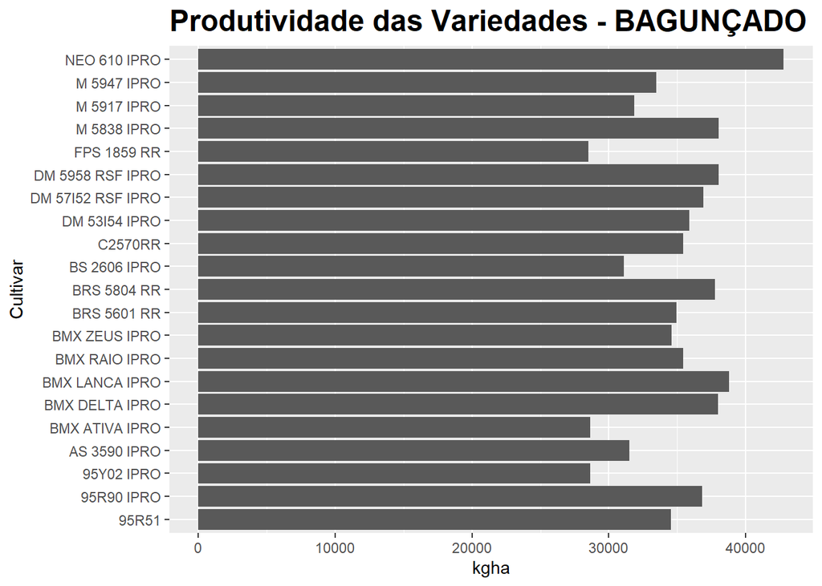

```r
ggplot(data = df_1) +
  geom_col(mapping = aes(x = kgha, y = Cultivar)) +
  ggtitle("Produtividade das Variedades - BAGUNÇADO") +
  theme(plot.title = element_text(color = "black", size = 18, face = "bold"))
```

## Melhorando a visualização

Facilitando o entendimento, organizamos dos dados, ordenando as produtividades em ordem decrescente.

```r
df_organizado <- df_1 %>%
  group_by(Cultivar) %>%
  summarise(kgha = mean(kgha)) %>%
  arrange(desc(kgha)) %>%
  mutate(Cultivar = fct_reorder(Cultivar, kgha))
```

O novo gráfico:

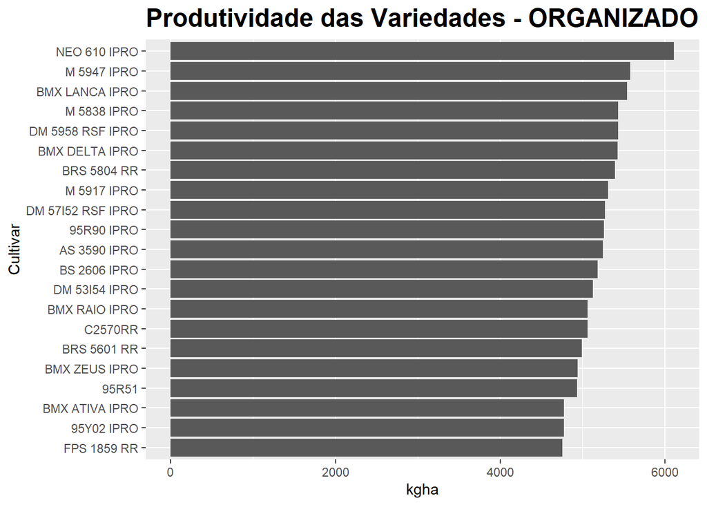

```r
ggplot(data = df_organizado) +
  geom_col(mapping = aes(x = kgha, y = Cultivar)) +
  ggtitle("Produtividade das Variedades - ORGANIZADO") +
  theme(plot.title = element_text(color = "black", size = 18, face = "bold"))
```

# Conclusão

Quando organizamos a visualização dos gráficos, facilitamos a interpretação do leitor e anossa também.